# AREE Methylation Workflow Report

CIBNOR2021_HEAT_RRSS / rr_vs_ss_day30_oscillating_heat

## Run identification

- **Study ID:** CIBNOR2021_HEAT_RRSS
- **Comparison ID:** rr_vs_ss_day30_oscillating_heat
- **Mode:** raw_reanalysis
- **Regions in standardized table:** 132587

```
Workflow: aree-methylation 0.1.0-scaffold
Generated: 2026-10-16T15:53:23.785171-07:00

Warnings:
 - software_version_unresolved: BISMARK_DEDUPLICATE wrote an empty version for bismark (version command failed or tool missing)
 - software_version_unresolved: BISMARK_METHYLATION_EXTRACTOR wrote an empty version for bismark (version command failed or tool missing)
```

## Hyper vs. hypo methylation

| Direction | N regions |
| --- | --- |
| hyper | 62617 |
| hypo | 69970 |

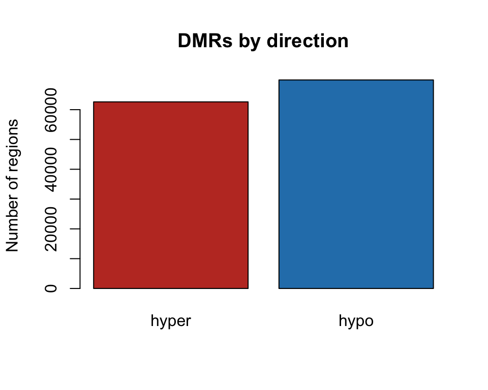

## Genomic context distribution

| Annotation context | N regions |
| --- | --- |
| gene_body | 31166 |
| intergenic | 101421 |

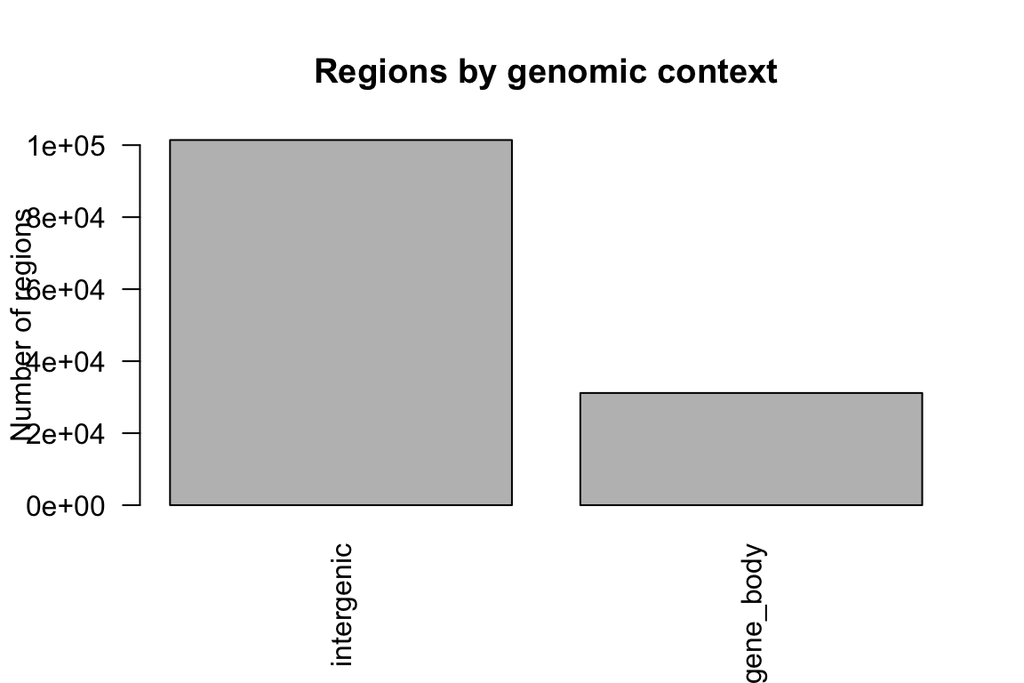

## Intergenic / gene-less regions

Regions with no associated `gene_id` are intentionally retained in the standardized table (not dropped) and are harmonized downstream as `genomic_region` features with `mapping_confidence = unresolved` (see `src/harmonize/methylation.py`).

```
101421 of 132587 regions have no gene_id (kept as intergenic/unresolved).
```

## Standardized region table

Showing the 500 regions with the smallest q-values of 132,587. The full table is `CIBNOR2021_HEAT_RRSS_rr_vs_ss_day30_oscillating_heat_dmr_standardized.tsv`.

| region_id | chrom | start | end | gene_id | annotation_context | meth_diff_percent | qvalue | direction | pvalue | se_meth_diff_percent | analysis_method |
| --- | --- | --- | --- | --- | --- | --- | --- | --- | --- | --- | --- |
| GENE_LOC105318540 | NC_088858.1 | 6978457 | 6992353 | LOC105318540 | gene_body | -6.925 | 0.5715 | hypo | 0.0006622 | 2.0340 | limma_pooled_genes |
| GENE_LOC105318745 | NC_088855.1 | 2395493 | 2409065 | LOC105318745 | gene_body | -20.651 | 0.5715 | hypo | 0.0005625 | 5.9870 | limma_pooled_genes |
| GENE_LOC105326162 | NC_088857.1 | 39704272 | 39709441 | LOC105326162 | gene_body | 9.312 | 0.5715 | hyper | 0.0006178 | 2.7200 | limma_pooled_genes |
| GENE_LOC105328116 | NC_088855.1 | 20696771 | 20701935 | LOC105328116 | gene_body | -12.316 | 0.5715 | hypo | 0.0002437 | 3.3570 | limma_pooled_genes |
| GENE_LOC105338661 | NC_088854.1 | 33898540 | 33904455 | LOC105338661 | gene_body | -8.165 | 0.5715 | hypo | 0.0003260 | 2.2720 | limma_pooled_genes |
| GENE_LOC105339312 | NC_088856.1 | 6008246 | 6018515 | LOC105339312 | gene_body | -5.456 | 0.5715 | hypo | 0.0005567 | 1.5810 | limma_pooled_genes |
| GENE_LOC109617414 | NC_088853.1 | 29435087 | 29440450 | LOC109617414 | gene_body | 25.029 | 0.5715 | hyper | 0.0001638 | 6.6410 | limma_pooled_genes |
| GENE_LOC109618586 | NC_088854.1 | 42436180 | 42441469 | LOC109618586 | gene_body | -21.039 | 0.5715 | hypo | 0.0002704 | 5.7770 | limma_pooled_genes |
| GENE_LOC109619173 | NC_088853.1 | 25433734 | 25443887 | LOC109619173 | gene_body | 48.023 | 0.5715 | hyper | 0.0007520 | 14.2500 | limma_pooled_genes |
| GENE_LOC117680957 | NC_088854.1 | 5620337 | 5623920 | LOC117680957 | gene_body | 9.456 | 0.5715 | hyper | 0.0004751 | 2.7060 | limma_pooled_genes |
| GENE_LOC117683293 | NC_088855.1 | 28644881 | 28650646 | LOC117683293 | gene_body | 7.189 | 0.5715 | hyper | 0.0007059 | 2.1220 | limma_pooled_genes |
| GENE_LOC117684500 | NC_088859.1 | 39121806 | 39124351 | LOC117684500 | gene_body | 11.292 | 0.5715 | hyper | 0.0008279 | 3.3770 | limma_pooled_genes |
| GENE_LOC117686399 | NC_088860.1 | 35308481 | 35317620 | LOC117686399 | gene_body | -12.239 | 0.5715 | hypo | 0.0004991 | 3.5160 | limma_pooled_genes |
| GENE_LOC117686639 | NC_088855.1 | 16168743 | 16170941 | LOC117686639 | gene_body | -12.963 | 0.5715 | hypo | 0.0001202 | 3.3710 | limma_pooled_genes |
| GENE_LOC136271718 | NC_088861.1 | 49066195 | 49081314 | LOC136271718 | gene_body | 11.877 | 0.5715 | hyper | 0.0001519 | 3.1360 | limma_pooled_genes |
| GENE_LOC136273023 | NC_088854.1 | 42431292 | 42438999 | LOC136273023 | gene_body | -27.746 | 0.5715 | hypo | 0.0001080 | 7.1660 | limma_pooled_genes |
| GENE_LOC136273066 | NC_088853.1 | 69134560 | 69136642 | LOC136273066 | gene_body | 13.243 | 0.5715 | hyper | 0.0003795 | 3.7260 | limma_pooled_genes |
| GENE_LOC136275142 | NC_088856.1 | 23055409 | 23057991 | LOC136275142 | gene_body | 23.526 | 0.5715 | hyper | 0.0002467 | 6.4180 | limma_pooled_genes |
| GENE_LOC136275168 | NC_088856.1 | 30884861 | 30890674 | LOC136275168 | gene_body | -22.573 | 0.5715 | hypo | 0.0005756 | 6.5560 | limma_pooled_genes |
| GENE_LOC136276570 | NC_088858.1 | 19343961 | 19346277 | LOC136276570 | gene_body | -23.142 | 0.5715 | hypo | 0.0006500 | 6.7870 | limma_pooled_genes |
| TILE_NC_088853.1_4500001 | NC_088853.1 | 4500001 | 4501000 |  | intergenic | -17.019 | 0.5715 | hypo | 0.0002790 | 4.6830 | limma_pooled_genes |
| TILE_NC_088853.1_4501001 | NC_088853.1 | 4501001 | 4502000 |  | intergenic | -14.522 | 0.5715 | hypo | 0.0003642 | 4.0740 | limma_pooled_genes |
| TILE_NC_088853.1_4503001 | NC_088853.1 | 4503001 | 4504000 |  | intergenic | -7.149 | 0.5715 | hypo | 0.0002976 | 1.9760 | limma_pooled_genes |
| TILE_NC_088853.1_4837001 | NC_088853.1 | 4837001 | 4838000 |  | intergenic | 4.944 | 0.5715 | hyper | 0.0008178 | 1.4770 | limma_pooled_genes |
| TILE_NC_088853.1_5213001 | NC_088853.1 | 5213001 | 5214000 |  | intergenic | 31.274 | 0.5715 | hyper | 0.0000950 | 8.0130 | limma_pooled_genes |
| TILE_NC_088853.1_13179001 | NC_088853.1 | 13179001 | 13180000 |  | intergenic | 26.572 | 0.5715 | hyper | 0.0001205 | 6.9110 | limma_pooled_genes |
| TILE_NC_088853.1_15165001 | NC_088853.1 | 15165001 | 15166000 |  | intergenic | 5.784 | 0.5715 | hyper | 0.0008049 | 1.7260 | limma_pooled_genes |
| TILE_NC_088853.1_22669001 | NC_088853.1 | 22669001 | 22670000 |  | intergenic | 12.084 | 0.5715 | hyper | 0.0005317 | 3.4880 | limma_pooled_genes |
| TILE_NC_088853.1_23936001 | NC_088853.1 | 23936001 | 23937000 |  | intergenic | -22.027 | 0.5715 | hypo | 0.0005319 | 6.3590 | limma_pooled_genes |
| TILE_NC_088853.1_26003001 | NC_088853.1 | 26003001 | 26004000 |  | intergenic | -6.600 | 0.5715 | hypo | 0.0008086 | 1.9700 | limma_pooled_genes |

[output cut: 470 more lines]

## Provenance

```
List of 16
 $ workflow_name                 : chr "aree-methylation"
 $ workflow_version              : chr "0.1.0-scaffold"
 $ study_id                      : chr "CIBNOR2021_HEAT_RRSS"
 $ comparison_id                 : chr "rr_vs_ss_day30_oscillating_heat"
 $ mode                          : chr "raw_reanalysis"
 $ date_generated                : chr "2026-10-16T15:53:23.785171-07:00"
 $ generated_by                  : chr "automated:aree-methylation@0.1.0-scaffold"
 $ parameters                    :List of 19
 $ input_checksums               :List of 4
 $ software_versions             :List of 11
 $ software_versions_not_captured:List of 1
 $ container_engine              : NULL
 $ qc_metrics                    :List of 5
 $ warnings                      : chr [1:2] "software_version_unresolved: BISMARK_DEDUPLICATE wrote an empty version for bismark (version command failed or tool missing)" "software_version_unresolved: BISMARK_METHYLATION_EXTRACTOR wrote an empty version for bismark (version command "| __truncated__
 $ output_schema                 : chr [1:9] "region_id" "chrom" "start" "end" ...
 $ harmonize_command             : chr "aree harmonize --study CIBNOR2021_HEAT_RRSS --input CIBNOR2021_HEAT_RRSS_rr_vs_ss_day30_oscillating_heat_dmr_standardized.tsv"
```